# 511-2017-09-13-cells

2017-09-13 15:42:03

## Announcements

- **Quiz 1** Friday
  - 13 questions/15 points
  - Take-home, take 30 min

## Today's Topics

- Cells of the nervous system
  - Glia
  - Neurons

## Visualizing the microanatomy of the brain

[video not shown]

## Crowd-sourcing anatomy research with [EyeWire](http://eyewire.org)

[video not shown]

## How many neurons and glia?

*"These findings challenge the common view that humans stand out from other primates in their brain composition and indicate that, with regard to numbers of neuronal and nonneuronal cells, the human brain is an isometrically scaled-up primate brain."*

[(Azevedo et al. 2009)](http://doi.org/10.1002/cne.21974)

## Mass, Neurons, Non-Neurons

[figure not shown]

[(Azevedo et al. 2009)](http://doi.org/10.1002/cne.21974)

## Neurons by brain mass

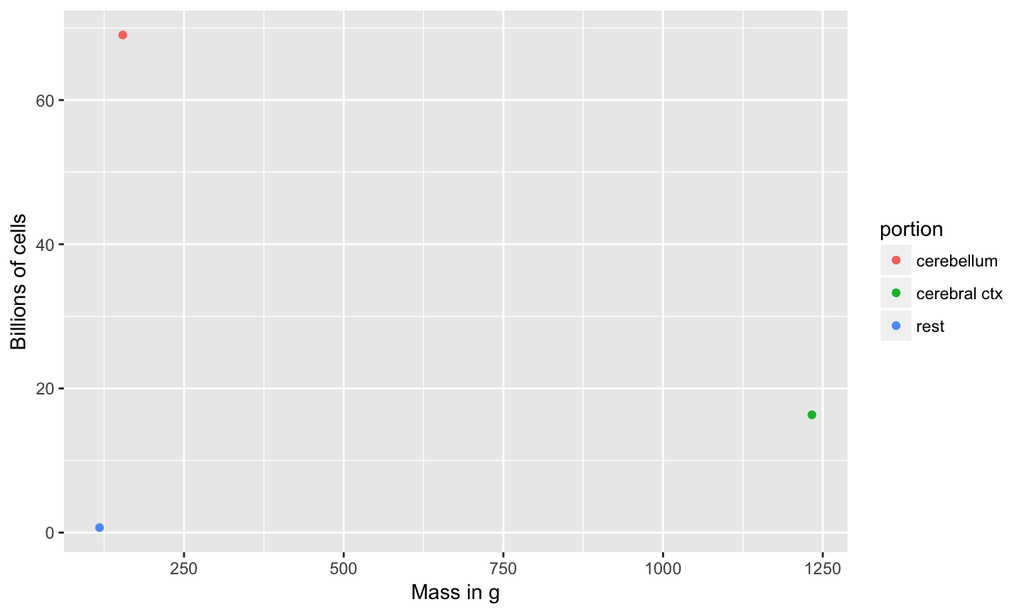

## Non-neuronal cells by brain mass

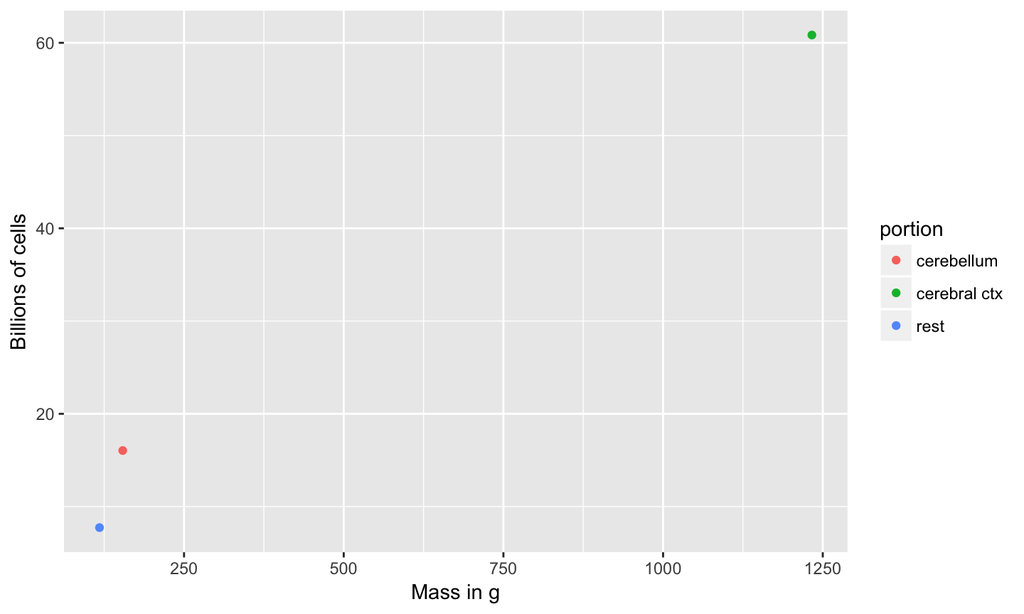

[figure not shown]

```r
brain %>% ggplot() +
  aes(x=mass_g, b_nonneurons, color=portion) +
  geom_point() +
  xlab("Mass in g") +
  ylab("Billions of cells")
```

## The Human Advantage

[figure not shown]

## Glia (neuroglia)

- Functions
  - Structural support
  - Metabolic support
  - Brain development

## Astrocytes

- "Star-shaped"
- Most numerous cell type in CNS
- Physical and metabolic support
  - Blood/brain barrier
  - Ion (Ca++/K+) buffering
  - Neurotransmitter (e.g., glutamate) buffering
  - Regulate local blood flow

## Astrocytes

- Shape brain development, [synaptic plasticity](https://en.wikipedia.org/wiki/Synaptic_plasticity)
- Disruption linked to cognitive impairment, disease [(Chung et al. 2015)](http://doi.org/10.1038/nn.4142)

## Astrocytes

[figure not shown]

https://upload.wikimedia.org/wikipedia/commons/5/56/Human_astrocyte.png

## Myelinating cells

- Oligodendrocytes
  - In brain and spinal cord (CNS)
  - 1:many neurons
- Schwann cells
  - In PNS
  - 1:1 neuron
  - Facilitate neuro-regeneration

## Oligodendrocytes

[figure not shown]

https://upload.wikimedia.org/wikipedia/commons/thumb/8/8a/Oligodendendrocytes_in_rat_brain.tif/lossy-page1-800px-Oligodendendrocytes_in_rat_brain.tif.jpg

## Schwann Cells

[figure not shown]

http://www.sciencellonline.com/media/catalog/product/cache/1/image/a6f8fb4f61eb724cff40f184d1fbcab0/m/1/m1700_3.jpg

## Microglia

- Phagocytosis
- Clean-up damaged, dead tissue
- Role in 'pruning' of synapses in normal development

## Microglia

[figure not shown]

http://www.the-scientist.com/images/JulyAug2017/microglia.jpg

## Macrostructure of neurons

- Dendrites
- Soma
- Axons
- Terminal buttons (boutons)

## Structure of neurons

[figure not shown]

https://upload.wikimedia.org/wikipedia/commons/thumb/a/a9/Complete_neuron_cell_diagram_en.svg/1280px-Complete_neuron_cell_diagram_en.svg.png

## Dendrites

- Majority of input to neuron
- Passive vs. active
- Spines

## Dendrites

[figure not shown]

http://i.livescience.com/images/i/000/058/588/original/brain-cell.jpg?1383065356

## Dendritic Spines

[figure not shown]

https://upload.wikimedia.org/wikipedia/commons/b/b1/Dendritic_spines.jpg

## Soma (cell body)

- Varied shapes
- Nucleus
  - Chromosomes
- Organelles
  - Mitochonrdria
  - Smooth and Rough Endoplasmic reticulum (ER)

## Soma

[figure not shown]

https://upload.wikimedia.org/wikipedia/commons/thumb/a/a9/Complete_neuron_cell_diagram_en.svg/1280px-Complete_neuron_cell_diagram_en.svg.png

## Axons

- Initial segment
- Nodes of Ranvier
- Terminals

## Axons

[figure not shown]

http://droualb.faculty.mjc.edu/Course%20Materials/Physiology%20101/Chapter%20Notes/Fall%202007/figure_07_02_labeled.jpg

## Synaptic bouton (terminal button)

- Synapse (~5-10K per neuron)
- Pre and postsynaptic membranes
- Synaptic cleft
- Synaptic vesicles
  - Store/release neurotransmitters
- Autoreceptors & transporters

## Synaptic bouton (terminal button)

[figure not shown]

http://antranik.org/wp-content/uploads/2012/04/synapse.jpg

## Classifying neurons

- Functional role
  - Input (sensory), output (motor/secretory), interneurons
- Anatomy
  - Unipolar
  - Bipolar
  - Multipolar

## Branching types

[figure not shown]

https://upload.wikimedia.org/wikipedia/commons/thumb/9/92/Neurons_uni_bi_multi_pseudouni.svg/2000px-Neurons_uni_bi_multi_pseudouni.svg.pngg

## Classifying neurons

- By specific anatomy
  - Pyramidal cells
  - Stellate cells
  - Purkinje cells
  - Granule cells

## Neurons by type

[figure not shown]

http://blogs.scientificamerican.com/brainwaves/files/2012/05/selection-glamor-FINAL-300x225.jpg

## Morphology, physiology, gene transcription

[figure not shown]

[Zeng & Sanes, 2017](http://doi.org/0.1038/nrn.2017.85)

[figure not shown]

[Zeng & Sanes, 2017](http://doi.org/0.1038/nrn.2017.85)

## Next time

- **Quiz 1** (available after class)
- Neurophysiology

## References

Azevedo, Frederico AC, Ludmila RB Carvalho, Lea T Grinberg, José Marcelo Farfel, Renata EL Ferretti, Renata EP Leite, Roberto Lent, Suzana Herculano-Houzel, and others. 2009. “Equal Numbers of Neuronal and Nonneuronal Cells Make the Human Brain an Isometrically Scaled-up Primate Brain.” *Journal of Comparative Neurology* 513 (5). Wiley Online Library: 532–41. doi:10.1002/cne.21974.

Chung, Won-Suk, Christina A. Welsh, Ben A. Barres, and Beth Stevens. 2015. “Do Glia Drive Synaptic and Cognitive Impairment in Disease?” *Nature Neuroscience* 18 (11): 1539–45. doi:10.1038/nn.4142.